# Combining depRS and PRS for binary MDD

2025-05-09

This script contains supplemental analyses predicting **binary** lifetime MDD at Year 2 from depRS and MDD PRS from the 2025 PGC GWAS. PRS for EUR participants are estimated using **European-only sumstats**, PRS for AFR, EAS and AMR participants are estimated using the **diverse ancestry sumstats**. PRS for AMR participants were estimated with the EUR ancestry LD matrix. depRS was trained to predict **continuous** CBCL DSM5-oriented depression subscale scores - measured at Year 2 - from 23 environmental factors measured at baseline. depRS and PRS are mean centred and standardised for comparison of ORs.

For (a) self-reported and (b) parent-reported lifetime MDD, we compare the following models:

Single predictor:  
(m1depRS) Y2 MDD ~ depRS  
(m1PRS) Y2 MDD ~ PRS

(m2) Y2 MDD ~ depRS + PRS  
(m3) Y2 MDD ~ depRS*PRS

```r
mdd2025 = readRDS("G://users/eileen/ABCD/ABCD_Environmental_Risk/ABCDv5.1/DATA/mdd25_prs.rds")
PRS = bind_rows(mdd2025$afr, mdd2025$eas, mdd2025$amr_diverse, mdd2025$eur_european)

depRS = readRDS("G://users/eileen/ABCD/ABCD_Environmental_Risk/ABCDv5.1/DATA/depRS_long.rds") |>
  select(src_subject_id, lambda.min)

scores = merge(depRS, PRS, by.x = "src_subject_id", by.y = "IID") |>
  mutate(across(where(is.numeric), scale)) |>
  mutate(across(where(is.matrix), as.numeric))
names(scores) = c("src_subject_id", "depRS", "PRS")
```

depRS was available for N=7029 participants.  
PRS was available for N=10647 participants.

A total N=6343 participants had complete depRS and PRS data. Analyses will be conducted in this sample.

```r
rm(depRS, PRS)
```

# (a) Youth self-reported MDD

```r
mddy = readRDS("G://users/eileen/ABCD/ABCD_Environmental_Risk/ABCDv5.1/DATA/ksads_y.rds")

dat.y = merge(scores, mddy$y2, by = "src_subject_id")

dat.y |> summarise(
  N = n(),
  LifetimeMDD = sum(mdd_lifetime=="1"),
  NoMDD = sum(mdd_lifetime=="0")
) |> kbl(digits = 3)
```

| N | LifetimeMDD | NoMDD |
| --- | --- | --- |
| 6299 | 211 | 6088 |

```r
prs_youth = dat.y |> select(src_subject_id, mdd_lifetime)
```

Of the N=6299 participants with self-reported MDD data at year 2, there were N=211 lifetime MDD cases.

## Model comparisons

```r
m1depRS.y = glm(mdd_lifetime ~ depRS, dat.y, family = binomial(link = "logit"))
m1PRS.y = glm(mdd_lifetime ~ PRS, dat.y, family = binomial(link = "logit"))

m2.y = glm(mdd_lifetime ~ depRS + PRS,
         dat.y, family = binomial(link = "logit"))
m3.y = glm(mdd_lifetime ~ depRS*PRS,
         dat.y, family = binomial(link = "logit"))
```

### ~ depRS

```r
test_performance(m1depRS.y, m2.y, m3.y) |> display(digits=3)
```

| Name | Model | BF | df | df_diff | Chi2 | p |
| --- | --- | --- | --- | --- | --- | --- |
| m1depRS.y | glm |  | 2 |  |  |  |
| m2.y | glm | 2.73 | 3 | 1.000 | 10.756 | 0.001 |
| m3.y | glm | 0.013 | 4 | 1.000 | 0.065 | 0.798 |

Models were detected as nested (in terms of fixed parameters) and are compared in sequential order.

### ~ PRS

```r
test_performance(m1PRS.y, m2.y, m3.y) |> display(digits=3)
```

| Name | Model | BF | df | df_diff | Chi2 | p |
| --- | --- | --- | --- | --- | --- | --- |
| m1PRS.y | glm |  | 2 |  |  |  |
| m2.y | glm | > 1000 | 3 | 1.000 | 47.141 | < .001 |
| m3.y | glm | 0.013 | 4 | 1.000 | 0.065 | 0.798 |

Models were detected as nested (in terms of fixed parameters) and are compared in sequential order.

## Performance metrics

```r
mods.y = list(m1depRS.y, m1PRS.y, m2.y, m3.y)

compare_performance(mods.y, verbose = F) |>
  mutate(Name = c("depRS", "PRS", "depRS+PRS", "depRS*PRS")) |>
  kable(digits = 3) |> kable_styling()
```

| Name | Model | AIC | AIC_wt | AICc | AICc_wt | BIC | BIC_wt | R2_Tjur | RMSE | Sigma | Log_loss | Score_log | Score_spherical | PCP |
| --- | --- | --- | --- | --- | --- | --- | --- | --- | --- | --- | --- | --- | --- | --- |
| depRS | glm | 1799.689 | 0.009 | 1799.691 | 0.009 | 1813.185 | 0.266 | 0.010 | 0.179 | 1 | 0.143 | -7.161 | 0.007 | 0.936 |
| PRS | glm | 1836.074 | 0.000 | 1836.075 | 0.000 | 1849.570 | 0.000 | 0.003 | 0.180 | 1 | 0.145 | -7.131 | 0.004 | 0.935 |
| depRS+PRS | glm | 1790.933 | 0.718 | 1790.937 | 0.718 | 1811.177 | 0.725 | 0.012 | 0.179 | 1 | 0.142 | -7.168 | 0.006 | 0.936 |
| depRS*PRS | glm | 1792.867 | 0.273 | 1792.874 | 0.273 | 1819.860 | 0.009 | 0.013 | 0.179 | 1 | 0.142 | -7.169 | 0.006 | 0.936 |

```r
lapply(mods.y, performance_accuracy) |>
  lapply(as.data.frame) |>
  bind_rows(.id = "model") |>
  mutate(model = c("depRS", "PRS", "depRS+PRS", "depRS*PRS")) |>
  kable(digits = 3) |> kable_styling()
```

| model | Accuracy | SE | CI | CI_low | CI_high | Method |
| --- | --- | --- | --- | --- | --- | --- |
| depRS | 0.640 | 0.035 | 0.95 | 0.592 | 0.681 | Area under Curve |
| PRS | 0.592 | 0.066 | 0.95 | 0.512 | 0.681 | Area under Curve |
| depRS+PRS | 0.651 | 0.039 | 0.95 | 0.603 | 0.700 | Area under Curve |
| depRS*PRS | 0.651 | 0.022 | 0.95 | 0.618 | 0.671 | Area under Curve |

## Model estimates

```r
sjPlot::tab_model(mods.y, dv.labels = c("depRS", "PRS", "depRS+PRS", "depRS*PRS"), collapse.ci = T, show.se = T, show.stat = T)
```

|  | depRS |  |  |  | PRS |  |  |  | depRS+PRS |  |  |  | depRS*PRS |  |  |  |
| --- | --- | --- | --- | --- | --- | --- | --- | --- | --- | --- | --- | --- | --- | --- | --- | --- |
| Predictors | Odds Ratios | std. Error | Statistic | p | Odds Ratios | std. Error | Statistic | p | Odds Ratios | std. Error | Statistic | p | Odds Ratios | std. Error | Statistic | p |
| (Intercept) | 0.03 (0.03 – 0.04) | 0.00 | -45.81 | **<0.001** | 0.03 (0.03 – 0.04) | 0.00 | -46.90 | **<0.001** | 0.03 (0.03 – 0.04) | 0.00 | -45.15 | **<0.001** | 0.03 (0.03 – 0.04) | 0.00 | -45.21 | **<0.001** |
| depRS | 1.53 (1.37 – 1.71) | 0.08 | 7.75 | **<0.001** |  |  |  |  | 1.51 (1.35 – 1.68) | 0.08 | 7.33 | **<0.001** | 1.50 (1.33 – 1.68) | 0.09 | 6.93 | **<0.001** |
| PRS |  |  |  |  | 1.33 (1.15 – 1.52) | 0.09 | 3.99 | **<0.001** | 1.26 (1.10 – 1.45) | 0.09 | 3.26 | **0.001** | 1.25 (1.08 – 1.46) | 0.10 | 2.92 | **0.003** |
| depRS × PRS |  |  |  |  |  |  |  |  |  |  |  |  | 1.01 (0.91 – 1.13) | 0.06 | 0.26 | 0.798 |
| Observations | 6299 |  |  |  | 6299 |  |  |  | 6299 |  |  |  | 6299 |  |  |  |
| R<sup>2</sup> Tjur | 0.010 |  |  |  | 0.003 |  |  |  | 0.012 |  |  |  | 0.013 |  |  |  |

## ROC curves

```r
#ROC curves for each model
dat.y = dat.y |> mutate(
  m1depRS = m1depRS.y$fitted.values,
  m1PRS = m1PRS.y$fitted.values,
  m2 = m2.y$fitted.values,
  m3 = m3.y$fitted.values
)

mods = c("m1depRS", "m1PRS", "m2", "m3")

rocs.y = list()
for (m in 1:length(mods.y)) {
  out = roc(dat.y$mdd_lifetime, dat.y[,mods[m]],
            ci = TRUE, auc = TRUE)
  rocs.y[[mods[m]]] = out
}
```

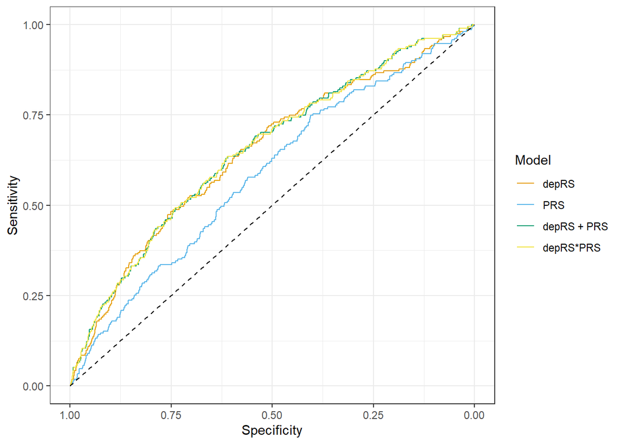

```r
youth = ggroc(list("depRS" = rocs.y$m1depRS, "PRS" = rocs.y$m1PRS, "depRS + PRS" = rocs.y$m2, "depRS*PRS" = rocs.y$m3)) +
  scale_color_manual(values = pal) +
  geom_segment(aes(x=1, y=0, xend=0, yend=1), colour = "black", alpha = 0.7, linetype = "dashed") +
  theme_bw() +
  labs(x = "Specificity", y = "Sensitivity", color = "Model")

youth
```

```r
#par("din")
```

# (b) Parent-reported MDD

```r
mddp = readRDS("G://users/eileen/ABCD/ABCD_Environmental_Risk/ABCDv5.1/DATA/ksads_p.rds")

dat.p = merge(scores, mddp$y2, by = "src_subject_id")

dat.p |> summarise(
  N = n(),
  LifetimeMDD = sum(mdd_lifetime=="1"),
  NoMDD = sum(mdd_lifetime=="0")
) |> kbl(digits = 3)
```

| N | LifetimeMDD | NoMDD |
| --- | --- | --- |
| 6259 | 248 | 6011 |

```r
prs_parent = dat.p |> select(src_subject_id, mdd_lifetime)
```

## Model comparisons

```r
m1depRS.p = glm(mdd_lifetime ~ depRS, dat.p, family = binomial(link = "logit"))
m1PRS.p = glm(mdd_lifetime ~ PRS, dat.p, family = binomial(link = "logit"))

m2.p = glm(mdd_lifetime ~ depRS + PRS,
         dat.p, family = binomial(link = "logit"))
m3.p = glm(mdd_lifetime ~ depRS*PRS,
         dat.p, family = binomial(link = "logit"))
```

### ~ depRS

```r
test_performance(m1depRS.p, m2.p, m3.p) |> display(digits=3)
```

| Name | Model | BF | df | df_diff | Chi2 | p |
| --- | --- | --- | --- | --- | --- | --- |
| m1depRS.p | glm |  | 2 |  |  |  |
| m2.p | glm | 270.57 | 3 | 1.000 | 19.943 | < .001 |
| m3.p | glm | 0.013 | 4 | 1.000 | 0.019 | 0.890 |

Models were detected as nested (in terms of fixed parameters) and are compared in sequential order.

### ~ PRS

```r
test_performance(m1PRS.p, m2.p, m3.p) |> display(digits=3)
```

| Name | Model | BF | df | df_diff | Chi2 | p |
| --- | --- | --- | --- | --- | --- | --- |
| m1PRS.p | glm |  | 2 |  |  |  |
| m2.p | glm | > 1000 | 3 | 1.000 | 96.130 | < .001 |
| m3.p | glm | 0.013 | 4 | 1.000 | 0.019 | 0.890 |

Models were detected as nested (in terms of fixed parameters) and are compared in sequential order.

## Performance metrics

```r
mods.p = list(m1depRS.p, m1PRS.p, m2.p, m3.p)

compare_performance(mods.p, verbose = F) |>
  mutate(Name = c("depRS", "PRS", "depRS+PRS", "depRS*PRS")) |>
  kable(digits = 3) |> kable_styling()
```

| Name | Model | AIC | AIC_wt | AICc | AICc_wt | BIC | BIC_wt | R2_Tjur | RMSE | Sigma | Log_loss | Score_log | Score_spherical | PCP |
| --- | --- | --- | --- | --- | --- | --- | --- | --- | --- | --- | --- | --- | --- | --- |
| depRS | glm | 1984.620 | 0.000 | 1984.621 | 0.000 | 1998.103 | 0.004 | 0.024 | 0.193 | 1 | 0.158 | -10.071 | 0.006 | 0.926 |
| PRS | glm | 2060.807 | 0.000 | 2060.809 | 0.000 | 2074.290 | 0.000 | 0.005 | 0.195 | 1 | 0.164 | -9.959 | 0.002 | 0.924 |
| depRS+PRS | glm | 1966.677 | 0.729 | 1966.681 | 0.729 | 1986.902 | 0.984 | 0.028 | 0.192 | 1 | 0.157 | -10.092 | 0.005 | 0.926 |
| depRS*PRS | glm | 1968.658 | 0.271 | 1968.664 | 0.271 | 1995.625 | 0.013 | 0.028 | 0.192 | 1 | 0.157 | -10.091 | 0.005 | 0.926 |

```r
lapply(mods.p, performance_accuracy) |>
  lapply(as.data.frame) |>
  bind_rows(.id = "model") |>
  mutate(model = c("depRS", "PRS", "depRS+PRS", "depRS*PRS")) |>
  kable(digits = 3) |> kable_styling()
```

| model | Accuracy | SE | CI | CI_low | CI_high | Method |
| --- | --- | --- | --- | --- | --- | --- |
| depRS | 0.677 | 0.034 | 0.95 | 0.631 | 0.716 | Area under Curve |
| PRS | 0.612 | 0.027 | 0.95 | 0.587 | 0.652 | Area under Curve |
| depRS+PRS | 0.689 | 0.053 | 0.95 | 0.617 | 0.745 | Area under Curve |
| depRS*PRS | 0.705 | 0.061 | 0.95 | 0.652 | 0.791 | Area under Curve |

## Model estimates

```r
sjPlot::tab_model(mods.p, dv.labels = c("depRS", "PRS", "depRS+PRS", "depRS*PRS"), collapse.ci = T, show.se = T, show.stat = T)
```

|  | depRS |  |  |  | PRS |  |  |  | depRS+PRS |  |  |  | depRS*PRS |  |  |  |
| --- | --- | --- | --- | --- | --- | --- | --- | --- | --- | --- | --- | --- | --- | --- | --- | --- |
| Predictors | Odds Ratios | std. Error | Statistic | p | Odds Ratios | std. Error | Statistic | p | Odds Ratios | std. Error | Statistic | p | Odds Ratios | std. Error | Statistic | p |
| (Intercept) | 0.04 (0.03 – 0.04) | 0.00 | -46.01 | **<0.001** | 0.04 (0.03 – 0.04) | 0.00 | -47.48 | **<0.001** | 0.03 (0.03 – 0.04) | 0.00 | -45.08 | **<0.001** | 0.03 (0.03 – 0.04) | 0.00 | -44.93 | **<0.001** |
| depRS | 1.73 (1.57 – 1.91) | 0.09 | 11.03 | **<0.001** |  |  |  |  | 1.69 (1.53 – 1.87) | 0.09 | 10.43 | **<0.001** | 1.70 (1.53 – 1.88) | 0.09 | 9.98 | **<0.001** |
| PRS |  |  |  |  | 1.44 (1.26 – 1.63) | 0.09 | 5.50 | **<0.001** | 1.34 (1.18 – 1.53) | 0.09 | 4.43 | **<0.001** | 1.35 (1.17 – 1.56) | 0.10 | 4.02 | **<0.001** |
| depRS × PRS |  |  |  |  |  |  |  |  |  |  |  |  | 0.99 (0.90 – 1.10) | 0.05 | -0.14 | 0.890 |
| Observations | 6259 |  |  |  | 6259 |  |  |  | 6259 |  |  |  | 6259 |  |  |  |
| R<sup>2</sup> Tjur | 0.024 |  |  |  | 0.005 |  |  |  | 0.028 |  |  |  | 0.028 |  |  |  |

## ROC curves

```r
#ROC curves for each model
dat.p = dat.p |> mutate(
  m1depRS = m1depRS.p$fitted.values,
  m1PRS = m1PRS.p$fitted.values,
  m2 = m2.p$fitted.values,
  m3 = m3.p$fitted.values
)

mods = c("m1depRS", "m1PRS", "m2", "m3")

rocs.p = list()
for (m in 1:length(mods)) {
  out = roc(dat.p$mdd_lifetime, dat.p[,mods[m]],
            ci = TRUE, auc = TRUE)
  rocs.p[[mods[m]]] = out
}
```

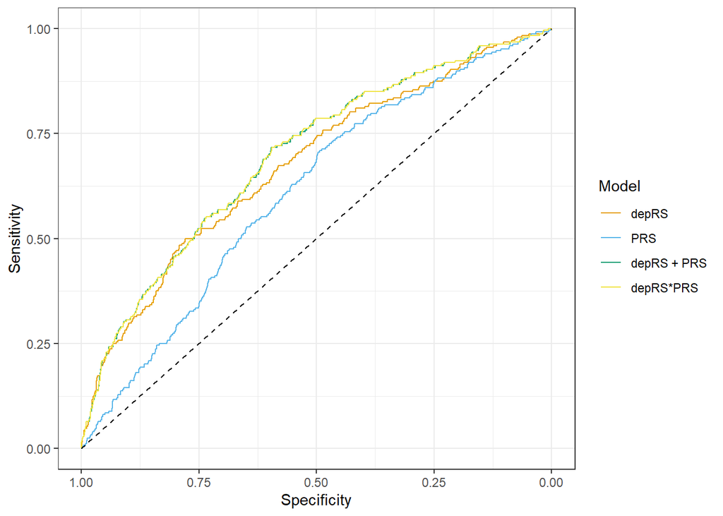

```r
parent = ggroc(list("depRS" = rocs.p$m1depRS, "PRS" = rocs.p$m1PRS, "depRS + PRS" = rocs.p$m2, "depRS*PRS" = rocs.p$m3)) +
  scale_color_manual(values = pal) +
  geom_segment(aes(x=1, y=0, xend=0, yend=1), colour = "black", alpha = 0.7, linetype = "dashed") +
  theme_bw() +
  labs(x = "Specificity", y = "Sensitivity", color = "Model")

parent
```

# ROC figure

```r
library(patchwork)

ptch_plot = youth + theme(legend.position = "none") + ggtitle("(a)") | parent + ggtitle("(b)")
```

```r
ggsave("C://Users/eilee/Desktop/PhD/Year 3/Drafts/envRS_paper/Figures/ROCs_sens.png", ptch_plot, device = "png", create.dir = TRUE, width = 9, height = 4, units = "in")
```

# Descriptives

## Youth self-reported MDD

```r
y.dat = readRDS("G://users/eileen/ABCD/ABCD_Environmental_Risk/ABCDv5.1/DATA/predictors_unrelatedIDs.rds") |> filter(src_subject_id %in% prs_youth$src_subject_id) |> select(src_subject_id, eventname, interview_age, gender_id, birthsex, race_ethnicity, income, parent_ed)

y2age = y.dat |> filter(eventname == "2_year_follow_up_y_arm_1") |> mutate(y2_age = interview_age/12) |> select(src_subject_id, y2_age)
y.base = y.dat |> filter(eventname=="baseline_year_1_arm_1") |> mutate(age_yrs = interview_age/12)

prs_youth = merge(prs_youth, y2age)
prs_youth = merge(prs_youth, y.base)
```

### Full sample

```r
summarytools::dfSummary(prs_youth[,-1],plain.ascii = F, style = "grid", valid.col = F, graph.col = T, varnumbers = F, tmp.img.dir = "/tmp", max.tbl.height = 300) |> print(method = "render")
```

NA

prs_youth

**Dimensions**: 6299 x 10  
**Duplicates**: 1166

| **Variable** | **Stats / Values** | **Freqs (% of Valid)** | **Graph** | **Missing** |
| --- | --- | --- | --- | --- |
| mdd_lifetime [factor] | 1. 0 2. 1 | 6088 ( 96.7% ) 211 ( 3.3% ) |  | 0 (0.0%) |
| y2_age [numeric] | Mean (sd) : 12 (0.7) min ≤ med ≤ max: 10.6 ≤ 12 ≤ 13.8 IQR (CV) : 1 (0.1) | 40 distinct values |  | 0 (0.0%) |
| eventname [factor] | 1. 1_year_follow_up_y_arm_1 2. 2_year_follow_up_y_arm_1 3. 3_year_follow_up_y_arm_1 4. 4_year_follow_up_y_arm_1 5. baseline_year_1_arm_1 | 0 ( 0.0% ) 0 ( 0.0% ) 0 ( 0.0% ) 0 ( 0.0% ) 6299 ( 100.0% ) |  | 0 (0.0%) |
| interview_age [integer] | Mean (sd) : 118.9 (7.4) min ≤ med ≤ max: 107 ≤ 119 ≤ 132 IQR (CV) : 13 (0.1) | 26 distinct values |  | 0 (0.0%) |
| gender_id [factor] | 1. M 2. F 3. Mtrans 4. Ftrans 5. GNC 6. Diff | 3366 ( 53.4% ) 2930 ( 46.5% ) 1 ( 0.0% ) 2 ( 0.0% ) 0 ( 0.0% ) 0 ( 0.0% ) |  | 0 (0.0%) |
| birthsex [factor] | 1. M 2. F 3. Intersex | 3370 ( 53.5% ) 2929 ( 46.5% ) 0 ( 0.0% ) |  | 0 (0.0%) |
| race_ethnicity [factor] | 1. White 2. Black 3. Hispanic 4. Asian 5. Other | 3778 ( 60.0% ) 794 ( 12.6% ) 1129 ( 17.9% ) 61 ( 1.0% ) 537 ( 8.5% ) |  | 0 (0.0%) |
| income [integer] | Mean (sd) : 7.4 (2.3) min ≤ med ≤ max: 1 ≤ 8 ≤ 10 IQR (CV) : 3 (0.3) | 1 : 175 ( 2.8% ) 2 : 210 ( 3.3% ) 3 : 134 ( 2.1% ) 4 : 257 ( 4.1% ) 5 : 362 ( 5.7% ) 6 : 545 ( 8.7% ) 7 : 904 ( 14.4% ) 8 : 974 ( 15.5% ) 9 : 2027 ( 32.2% ) 10 : 711 ( 11.3% ) |  | 0 (0.0%) |
| parent_ed [factor] | 1. Bachelor 2. HS/GED 3. less_HS 4. Postgraduate 5. Some_College | 1941 ( 30.8% ) 577 ( 9.2% ) 235 ( 3.7% ) 1738 ( 27.6% ) 1808 ( 28.7% ) |  | 0 (0.0%) |
| age_yrs [numeric] | Mean (sd) : 9.9 (0.6) min ≤ med ≤ max: 8.9 ≤ 9.9 ≤ 11 IQR (CV) : 1.1 (0.1) | 26 distinct values |  | 0 (0.0%) |

Generated by summarytools 1.1.3 ([R](https://www.r-project.org/) version 4.4.3)  
2025-05-09

### Lifetime MDD = 1

```r
prs_youth[,-1] |> filter(mdd_lifetime==1) |>
summarytools::dfSummary(plain.ascii = F, style = "grid", valid.col = F, graph.col = T, varnumbers = F, tmp.img.dir = "/tmp", max.tbl.height = 300) |> print(method = "render")
```

NA

prs_youth

**Dimensions**: 211 x 10  
**Duplicates**: 0

| **Variable** | **Stats / Values** | **Freqs (% of Valid)** | **Graph** | **Missing** |
| --- | --- | --- | --- | --- |
| mdd_lifetime [factor] | 1. 0 2. 1 | 0 ( 0.0% ) 211 ( 100.0% ) |  | 0 (0.0%) |
| y2_age [numeric] | Mean (sd) : 12.1 (0.7) min ≤ med ≤ max: 10.8 ≤ 12.2 ≤ 13.7 IQR (CV) : 1.1 (0.1) | 35 distinct values |  | 0 (0.0%) |
| eventname [factor] | 1. 1_year_follow_up_y_arm_1 2. 2_year_follow_up_y_arm_1 3. 3_year_follow_up_y_arm_1 4. 4_year_follow_up_y_arm_1 5. baseline_year_1_arm_1 | 0 ( 0.0% ) 0 ( 0.0% ) 0 ( 0.0% ) 0 ( 0.0% ) 211 ( 100.0% ) |  | 0 (0.0%) |
| interview_age [integer] | Mean (sd) : 119.5 (7.5) min ≤ med ≤ max: 107 ≤ 119 ≤ 132 IQR (CV) : 13.5 (0.1) | 26 distinct values |  | 0 (0.0%) |
| gender_id [factor] | 1. M 2. F 3. Mtrans 4. Ftrans 5. GNC 6. Diff | 82 ( 38.9% ) 129 ( 61.1% ) 0 ( 0.0% ) 0 ( 0.0% ) 0 ( 0.0% ) 0 ( 0.0% ) |  | 0 (0.0%) |
| birthsex [factor] | 1. M 2. F 3. Intersex | 81 ( 38.4% ) 130 ( 61.6% ) 0 ( 0.0% ) |  | 0 (0.0%) |
| race_ethnicity [factor] | 1. White 2. Black 3. Hispanic 4. Asian 5. Other | 95 ( 45.0% ) 41 ( 19.4% ) 49 ( 23.2% ) 2 ( 0.9% ) 24 ( 11.4% ) |  | 0 (0.0%) |
| income [integer] | Mean (sd) : 6.5 (2.5) min ≤ med ≤ max: 1 ≤ 7 ≤ 10 IQR (CV) : 3 (0.4) | 1 : 13 ( 6.2% ) 2 : 8 ( 3.8% ) 3 : 6 ( 2.8% ) 4 : 19 ( 9.0% ) 5 : 13 ( 6.2% ) 6 : 22 ( 10.4% ) 7 : 53 ( 25.1% ) 8 : 26 ( 12.3% ) 9 : 35 ( 16.6% ) 10 : 16 ( 7.6% ) |  | 0 (0.0%) |
| parent_ed [factor] | 1. Bachelor 2. HS/GED 3. less_HS 4. Postgraduate 5. Some_College | 53 ( 25.1% ) 26 ( 12.3% ) 17 ( 8.1% ) 36 ( 17.1% ) 79 ( 37.4% ) |  | 0 (0.0%) |
| age_yrs [numeric] | Mean (sd) : 10 (0.6) min ≤ med ≤ max: 8.9 ≤ 9.9 ≤ 11 IQR (CV) : 1.1 (0.1) | 26 distinct values |  | 0 (0.0%) |

Generated by summarytools 1.1.3 ([R](https://www.r-project.org/) version 4.4.3)  
2025-05-09

### Lifetime MDD = 0

```r
prs_youth[,-1] |> filter(mdd_lifetime==0) |>
summarytools::dfSummary(plain.ascii = F, style = "grid", valid.col = F, graph.col = T, varnumbers = F, tmp.img.dir = "/tmp", max.tbl.height = 300) |> print(method = "render")
```

NA

prs_youth

**Dimensions**: 6088 x 10  
**Duplicates**: 1166

| **Variable** | **Stats / Values** | **Freqs (% of Valid)** | **Graph** | **Missing** |
| --- | --- | --- | --- | --- |
| mdd_lifetime [factor] | 1. 0 2. 1 | 6088 ( 100.0% ) 0 ( 0.0% ) |  | 0 (0.0%) |
| y2_age [numeric] | Mean (sd) : 12 (0.7) min ≤ med ≤ max: 10.6 ≤ 12 ≤ 13.8 IQR (CV) : 1.1 (0.1) | 40 distinct values |  | 0 (0.0%) |
| eventname [factor] | 1. 1_year_follow_up_y_arm_1 2. 2_year_follow_up_y_arm_1 3. 3_year_follow_up_y_arm_1 4. 4_year_follow_up_y_arm_1 5. baseline_year_1_arm_1 | 0 ( 0.0% ) 0 ( 0.0% ) 0 ( 0.0% ) 0 ( 0.0% ) 6088 ( 100.0% ) |  | 0 (0.0%) |
| interview_age [integer] | Mean (sd) : 118.9 (7.4) min ≤ med ≤ max: 107 ≤ 119 ≤ 132 IQR (CV) : 13 (0.1) | 26 distinct values |  | 0 (0.0%) |
| gender_id [factor] | 1. M 2. F 3. Mtrans 4. Ftrans 5. GNC 6. Diff | 3284 ( 53.9% ) 2801 ( 46.0% ) 1 ( 0.0% ) 2 ( 0.0% ) 0 ( 0.0% ) 0 ( 0.0% ) |  | 0 (0.0%) |
| birthsex [factor] | 1. M 2. F 3. Intersex | 3289 ( 54.0% ) 2799 ( 46.0% ) 0 ( 0.0% ) |  | 0 (0.0%) |
| race_ethnicity [factor] | 1. White 2. Black 3. Hispanic 4. Asian 5. Other | 3683 ( 60.5% ) 753 ( 12.4% ) 1080 ( 17.7% ) 59 ( 1.0% ) 513 ( 8.4% ) |  | 0 (0.0%) |
| income [integer] | Mean (sd) : 7.4 (2.3) min ≤ med ≤ max: 1 ≤ 8 ≤ 10 IQR (CV) : 3 (0.3) | 1 : 162 ( 2.7% ) 2 : 202 ( 3.3% ) 3 : 128 ( 2.1% ) 4 : 238 ( 3.9% ) 5 : 349 ( 5.7% ) 6 : 523 ( 8.6% ) 7 : 851 ( 14.0% ) 8 : 948 ( 15.6% ) 9 : 1992 ( 32.7% ) 10 : 695 ( 11.4% ) |  | 0 (0.0%) |
| parent_ed [factor] | 1. Bachelor 2. HS/GED 3. less_HS 4. Postgraduate 5. Some_College | 1888 ( 31.0% ) 551 ( 9.1% ) 218 ( 3.6% ) 1702 ( 28.0% ) 1729 ( 28.4% ) |  | 0 (0.0%) |
| age_yrs [numeric] | Mean (sd) : 9.9 (0.6) min ≤ med ≤ max: 8.9 ≤ 9.9 ≤ 11 IQR (CV) : 1.1 (0.1) | 26 distinct values |  | 0 (0.0%) |

Generated by summarytools 1.1.3 ([R](https://www.r-project.org/) version 4.4.3)  
2025-05-09

## Parent-reported MDD

```r
p.dat = readRDS("G://users/eileen/ABCD/ABCD_Environmental_Risk/ABCDv5.1/DATA/predictors_unrelatedIDs.rds") |> filter(src_subject_id %in% prs_parent$src_subject_id) |> select(src_subject_id, eventname, interview_age, gender_id, birthsex, race_ethnicity, income, parent_ed)

y2age = p.dat |> filter(eventname == "2_year_follow_up_y_arm_1") |> mutate(y2_age = interview_age/12) |> select(src_subject_id, y2_age)
p.base = p.dat |> filter(eventname=="baseline_year_1_arm_1") |> mutate(age_yrs = interview_age/12)

prs_parent = merge(prs_parent, y2age)
prs_parent = merge(prs_parent, p.base)
```

### Full sample

```r
summarytools::dfSummary(prs_parent[,-1],plain.ascii = F, style = "grid", valid.col = F, graph.col = T, varnumbers = F, tmp.img.dir = "/tmp", max.tbl.height = 300) |> print(method = "render")
```

NA

prs_parent

**Dimensions**: 6259 x 10  
**Duplicates**: 1137

| **Variable** | **Stats / Values** | **Freqs (% of Valid)** | **Graph** | **Missing** |
| --- | --- | --- | --- | --- |
| mdd_lifetime [factor] | 1. 0 2. 1 | 6011 ( 96.0% ) 248 ( 4.0% ) |  | 0 (0.0%) |
| y2_age [numeric] | Mean (sd) : 12 (0.7) min ≤ med ≤ max: 10.6 ≤ 12 ≤ 13.8 IQR (CV) : 1.1 (0.1) | 40 distinct values |  | 0 (0.0%) |
| eventname [factor] | 1. 1_year_follow_up_y_arm_1 2. 2_year_follow_up_y_arm_1 3. 3_year_follow_up_y_arm_1 4. 4_year_follow_up_y_arm_1 5. baseline_year_1_arm_1 | 0 ( 0.0% ) 0 ( 0.0% ) 0 ( 0.0% ) 0 ( 0.0% ) 6259 ( 100.0% ) |  | 0 (0.0%) |
| interview_age [integer] | Mean (sd) : 118.9 (7.4) min ≤ med ≤ max: 107 ≤ 119 ≤ 132 IQR (CV) : 13 (0.1) | 26 distinct values |  | 0 (0.0%) |
| gender_id [factor] | 1. M 2. F 3. Mtrans 4. Ftrans 5. GNC 6. Diff | 3334 ( 53.3% ) 2922 ( 46.7% ) 1 ( 0.0% ) 2 ( 0.0% ) 0 ( 0.0% ) 0 ( 0.0% ) |  | 0 (0.0%) |
| birthsex [factor] | 1. M 2. F 3. Intersex | 3338 ( 53.3% ) 2921 ( 46.7% ) 0 ( 0.0% ) |  | 0 (0.0%) |
| race_ethnicity [factor] | 1. White 2. Black 3. Hispanic 4. Asian 5. Other | 3764 ( 60.1% ) 784 ( 12.5% ) 1119 ( 17.9% ) 61 ( 1.0% ) 531 ( 8.5% ) |  | 0 (0.0%) |
| income [integer] | Mean (sd) : 7.4 (2.3) min ≤ med ≤ max: 1 ≤ 8 ≤ 10 IQR (CV) : 3 (0.3) | 1 : 172 ( 2.7% ) 2 : 207 ( 3.3% ) 3 : 133 ( 2.1% ) 4 : 255 ( 4.1% ) 5 : 361 ( 5.8% ) 6 : 538 ( 8.6% ) 7 : 900 ( 14.4% ) 8 : 969 ( 15.5% ) 9 : 2018 ( 32.2% ) 10 : 706 ( 11.3% ) |  | 0 (0.0%) |
| parent_ed [factor] | 1. Bachelor 2. HS/GED 3. less_HS 4. Postgraduate 5. Some_College | 1935 ( 30.9% ) 573 ( 9.2% ) 229 ( 3.7% ) 1728 ( 27.6% ) 1794 ( 28.7% ) |  | 0 (0.0%) |
| age_yrs [numeric] | Mean (sd) : 9.9 (0.6) min ≤ med ≤ max: 8.9 ≤ 9.9 ≤ 11 IQR (CV) : 1.1 (0.1) | 26 distinct values |  | 0 (0.0%) |

Generated by summarytools 1.1.3 ([R](https://www.r-project.org/) version 4.4.3)  
2025-05-09

### Lifetime MDD = 1

```r
prs_parent[,-1] |> filter(mdd_lifetime==1) |>
summarytools::dfSummary(plain.ascii = F, style = "grid", valid.col = F, graph.col = T, varnumbers = F, tmp.img.dir = "/tmp", max.tbl.height = 300) |> print(method = "render")
```

NA

prs_parent

**Dimensions**: 248 x 10  
**Duplicates**: 1

| **Variable** | **Stats / Values** | **Freqs (% of Valid)** | **Graph** | **Missing** |
| --- | --- | --- | --- | --- |
| mdd_lifetime [factor] | 1. 0 2. 1 | 0 ( 0.0% ) 248 ( 100.0% ) |  | 0 (0.0%) |
| y2_age [numeric] | Mean (sd) : 12.2 (0.7) min ≤ med ≤ max: 10.6 ≤ 12.2 ≤ 13.7 IQR (CV) : 1.2 (0.1) | 36 distinct values |  | 0 (0.0%) |
| eventname [factor] | 1. 1_year_follow_up_y_arm_1 2. 2_year_follow_up_y_arm_1 3. 3_year_follow_up_y_arm_1 4. 4_year_follow_up_y_arm_1 5. baseline_year_1_arm_1 | 0 ( 0.0% ) 0 ( 0.0% ) 0 ( 0.0% ) 0 ( 0.0% ) 248 ( 100.0% ) |  | 0 (0.0%) |
| interview_age [integer] | Mean (sd) : 120 (7.5) min ≤ med ≤ max: 107 ≤ 120 ≤ 132 IQR (CV) : 14 (0.1) | 26 distinct values |  | 0 (0.0%) |
| gender_id [factor] | 1. M 2. F 3. Mtrans 4. Ftrans 5. GNC 6. Diff | 123 ( 49.6% ) 124 ( 50.0% ) 1 ( 0.4% ) 0 ( 0.0% ) 0 ( 0.0% ) 0 ( 0.0% ) |  | 0 (0.0%) |
| birthsex [factor] | 1. M 2. F 3. Intersex | 124 ( 50.0% ) 124 ( 50.0% ) 0 ( 0.0% ) |  | 0 (0.0%) |
| race_ethnicity [factor] | 1. White 2. Black 3. Hispanic 4. Asian 5. Other | 141 ( 56.9% ) 28 ( 11.3% ) 45 ( 18.1% ) 3 ( 1.2% ) 31 ( 12.5% ) |  | 0 (0.0%) |
| income [integer] | Mean (sd) : 7.1 (2.2) min ≤ med ≤ max: 1 ≤ 8 ≤ 10 IQR (CV) : 3 (0.3) | 1 : 7 ( 2.8% ) 2 : 7 ( 2.8% ) 3 : 6 ( 2.4% ) 4 : 15 ( 6.0% ) 5 : 17 ( 6.9% ) 6 : 31 ( 12.5% ) 7 : 34 ( 13.7% ) 8 : 41 ( 16.5% ) 9 : 72 ( 29.0% ) 10 : 18 ( 7.3% ) |  | 0 (0.0%) |
| parent_ed [factor] | 1. Bachelor 2. HS/GED 3. less_HS 4. Postgraduate 5. Some_College | 72 ( 29.0% ) 18 ( 7.3% ) 5 ( 2.0% ) 69 ( 27.8% ) 84 ( 33.9% ) |  | 0 (0.0%) |
| age_yrs [numeric] | Mean (sd) : 10 (0.6) min ≤ med ≤ max: 8.9 ≤ 10 ≤ 11 IQR (CV) : 1.2 (0.1) | 26 distinct values |  | 0 (0.0%) |

Generated by summarytools 1.1.3 ([R](https://www.r-project.org/) version 4.4.3)  
2025-05-09

### Lifetime MDD = 0

```r
prs_parent[,-1] |> filter(mdd_lifetime==0) |>
summarytools::dfSummary(plain.ascii = F, style = "grid", valid.col = F, graph.col = T, varnumbers = F, tmp.img.dir = "/tmp", max.tbl.height = 300) |> print(method = "render")
```

NA

prs_parent

**Dimensions**: 6011 x 10  
**Duplicates**: 1136

| **Variable** | **Stats / Values** | **Freqs (% of Valid)** | **Graph** | **Missing** |
| --- | --- | --- | --- | --- |
| mdd_lifetime [factor] | 1. 0 2. 1 | 6011 ( 100.0% ) 0 ( 0.0% ) |  | 0 (0.0%) |
| y2_age [numeric] | Mean (sd) : 12 (0.7) min ≤ med ≤ max: 10.6 ≤ 12 ≤ 13.8 IQR (CV) : 1.1 (0.1) | 40 distinct values |  | 0 (0.0%) |
| eventname [factor] | 1. 1_year_follow_up_y_arm_1 2. 2_year_follow_up_y_arm_1 3. 3_year_follow_up_y_arm_1 4. 4_year_follow_up_y_arm_1 5. baseline_year_1_arm_1 | 0 ( 0.0% ) 0 ( 0.0% ) 0 ( 0.0% ) 0 ( 0.0% ) 6011 ( 100.0% ) |  | 0 (0.0%) |
| interview_age [integer] | Mean (sd) : 118.8 (7.4) min ≤ med ≤ max: 107 ≤ 119 ≤ 132 IQR (CV) : 13 (0.1) | 26 distinct values |  | 0 (0.0%) |
| gender_id [factor] | 1. M 2. F 3. Mtrans 4. Ftrans 5. GNC 6. Diff | 3211 ( 53.4% ) 2798 ( 46.5% ) 0 ( 0.0% ) 2 ( 0.0% ) 0 ( 0.0% ) 0 ( 0.0% ) |  | 0 (0.0%) |
| birthsex [factor] | 1. M 2. F 3. Intersex | 3214 ( 53.5% ) 2797 ( 46.5% ) 0 ( 0.0% ) |  | 0 (0.0%) |
| race_ethnicity [factor] | 1. White 2. Black 3. Hispanic 4. Asian 5. Other | 3623 ( 60.3% ) 756 ( 12.6% ) 1074 ( 17.9% ) 58 ( 1.0% ) 500 ( 8.3% ) |  | 0 (0.0%) |
| income [integer] | Mean (sd) : 7.4 (2.3) min ≤ med ≤ max: 1 ≤ 8 ≤ 10 IQR (CV) : 3 (0.3) | 1 : 165 ( 2.7% ) 2 : 200 ( 3.3% ) 3 : 127 ( 2.1% ) 4 : 240 ( 4.0% ) 5 : 344 ( 5.7% ) 6 : 507 ( 8.4% ) 7 : 866 ( 14.4% ) 8 : 928 ( 15.4% ) 9 : 1946 ( 32.4% ) 10 : 688 ( 11.4% ) |  | 0 (0.0%) |
| parent_ed [factor] | 1. Bachelor 2. HS/GED 3. less_HS 4. Postgraduate 5. Some_College | 1863 ( 31.0% ) 555 ( 9.2% ) 224 ( 3.7% ) 1659 ( 27.6% ) 1710 ( 28.4% ) |  | 0 (0.0%) |
| age_yrs [numeric] | Mean (sd) : 9.9 (0.6) min ≤ med ≤ max: 8.9 ≤ 9.9 ≤ 11 IQR (CV) : 1.1 (0.1) | 26 distinct values |  | 0 (0.0%) |

Generated by summarytools 1.1.3 ([R](https://www.r-project.org/) version 4.4.3)  
2025-05-09